# Sales Data Analysis

Clayton

2022-10-11

# Sales Data Analysis In R indcluding visualisations

This Analysis forms my first project in R which i will utilize the “tidyverse”,“dplyr”,“ggplot2” and “tidyr” libraries to manipulate data and produce some visuals.

## Step 1: Importing data data

The data is imported from an excel document into a data frame called foodsales.”all libraries already installed”

```r
library(readxl)
foodsales <- read_excel("documents/sampledatafoodsales.xlsx")
```

## Step 2: Loading Libraries

Here we load the libraries(all liraries already installed)

```r
library(tidyverse)
```

```r
library(dplyr)
library(ggplot2)
library(janitor)
library(dplyr)
library(tidyr)
library(lubridate)
options(dplyr.summarise.inform = FALSE)# this suppresses the summarise group warnings
```

## Step 2: Checking the Data and columns

Here we check the data to view the first few rows, chech the columns and a get a glimpse of the data

```r
head(foodsales)#Views the first 6 rows
```

```
## # A tibble: 6 × 8
##   OrderDate           Region City        Categ…¹ Product Quant…² UnitP…³ Total…⁴
##   <dttm>              <chr>  <chr>       <chr>   <chr>     <dbl>   <dbl>   <dbl>
## 1 2020-01-01 00:00:00 East   Boston      Bars    Carrot       33    1.77    58.4
## 2 2020-01-04 00:00:00 East   Boston      Cracke… Whole …      87    3.49   304.
## 3 2020-01-07 00:00:00 West   Los Angeles Cookies Chocol…      58    1.87   108.
## 4 2020-01-10 00:00:00 East   New York    Cookies Chocol…      82    1.87   153.
## 5 2020-01-13 00:00:00 East   Boston      Cookies Arrowr…      38    2.18    82.8
## 6 2020-01-16 00:00:00 East   Boston      Bars    Carrot       54    1.77    95.6
## # … with abbreviated variable names ¹Category, ²Quantity, ³UnitPrice,
## #   ⁴TotalPrice
```

```r
slice(foodsales,1:10) #Views the first 10 rows
```

```
## # A tibble: 10 × 8
##    OrderDate           Region City       Categ…¹ Product Quant…² UnitP…³ Total…⁴
##    <dttm>              <chr>  <chr>      <chr>   <chr>     <dbl>   <dbl>   <dbl>
##  1 2020-01-01 00:00:00 East   Boston     Bars    Carrot       33    1.77    58.4
##  2 2020-01-04 00:00:00 East   Boston     Cracke… Whole …      87    3.49   304.
##  3 2020-01-07 00:00:00 West   Los Angel… Cookies Chocol…      58    1.87   108.
##  4 2020-01-10 00:00:00 East   New York   Cookies Chocol…      82    1.87   153.
##  5 2020-01-13 00:00:00 East   Boston     Cookies Arrowr…      38    2.18    82.8
##  6 2020-01-16 00:00:00 East   Boston     Bars    Carrot       54    1.77    95.6
##  7 2020-01-19 00:00:00 East   Boston     Cracke… Whole …     149    3.49   520.
##  8 2020-01-22 00:00:00 West   Los Angel… Bars    Carrot       51    1.77    90.3
##  9 2020-01-25 00:00:00 East   New York   Bars    Carrot      100    1.77   177
## 10 2020-01-28 00:00:00 East   New York   Snacks  Potato…      28    1.35    37.8
## # … with abbreviated variable names ¹Category, ²Quantity, ³UnitPrice,
## #   ⁴TotalPrice
```

```r
colnames(foodsales)# Checks the column name headers
```

```
## [1] "OrderDate"  "Region"     "City"       "Category"   "Product"
## [6] "Quantity"   "UnitPrice"  "TotalPrice"
```

```r
str(foodsales) #check also the data types for the data
```

```
## tibble [244 × 8] (S3: tbl_df/tbl/data.frame)
##  $ OrderDate : POSIXct[1:244], format: "2020-01-01" "2020-01-04" ...
##  $ Region    : chr [1:244] "East" "East" "West" "East" ...
##  $ City      : chr [1:244] "Boston" "Boston" "Los Angeles" "New York" ...
##  $ Category  : chr [1:244] "Bars" "Crackers" "Cookies" "Cookies" ...
##  $ Product   : chr [1:244] "Carrot" "Whole Wheat" "Chocolate Chip" "Chocolate Chip" ...
##  $ Quantity  : num [1:244] 33 87 58 82 38 54 149 51 100 28 ...
##  $ UnitPrice : num [1:244] 1.77 3.49 1.87 1.87 2.18 1.77 3.49 1.77 1.77 1.35 ...
##  $ TotalPrice: num [1:244] 58.4 303.6 108.5 153.3 82.8 ...
```

## Step 2: clean the column names and check if all datatypes are correct

Before Analysis we clean the column names and check data types for the data

```r
my_sales_clean_data<-clean_names(foodsales) # Clean the data
#colnames(clean) # view the new column Names
my_sales_clean_data <- na.omit(my_sales_clean_data)#remove Nulls
slice(my_sales_clean_data,1:10) # View first 10 lines using the new columns
```

```
## # A tibble: 10 × 8
##    order_date          region city       categ…¹ product quant…² unit_…³ total…⁴
##    <dttm>              <chr>  <chr>      <chr>   <chr>     <dbl>   <dbl>   <dbl>
##  1 2020-01-01 00:00:00 East   Boston     Bars    Carrot       33    1.77    58.4
##  2 2020-01-04 00:00:00 East   Boston     Cracke… Whole …      87    3.49   304.
##  3 2020-01-07 00:00:00 West   Los Angel… Cookies Chocol…      58    1.87   108.
##  4 2020-01-10 00:00:00 East   New York   Cookies Chocol…      82    1.87   153.
##  5 2020-01-13 00:00:00 East   Boston     Cookies Arrowr…      38    2.18    82.8
##  6 2020-01-16 00:00:00 East   Boston     Bars    Carrot       54    1.77    95.6
##  7 2020-01-19 00:00:00 East   Boston     Cracke… Whole …     149    3.49   520.
##  8 2020-01-22 00:00:00 West   Los Angel… Bars    Carrot       51    1.77    90.3
##  9 2020-01-25 00:00:00 East   New York   Bars    Carrot      100    1.77   177
## 10 2020-01-28 00:00:00 East   New York   Snacks  Potato…      28    1.35    37.8
## # … with abbreviated variable names ¹category, ²quantity, ³unit_price,
## #   ⁴total_price
```

## Step 2: Analyse the data

### View Sales By Category

Here we do some analysis to check which categories had the most sales

```r
 my_sales_clean_data %>%
  select(city, category, product,order_date, quantity, unit_price, total_price) %>%
  group_by(category) %>%
summarise( total_sales_by_category = sum(total_price)) %>%
arrange(desc(total_sales_by_category))
```

```
## # A tibble: 4 × 2
##   category total_sales_by_category
##   <chr>                      <dbl>
## 1 Cookies                   17212.
## 2 Bars                      10536.
## 3 Crackers                   3340.
## 4 Snacks                     2238.
```

### View Sales By Product

Here we do some analysis to check which Products had the most sales

```r
 my_sales_clean_data %>%
  select(city, category, product,order_date, quantity, unit_price, total_price) %>%
  group_by(product) %>%
summarise( total_sales_by_product = sum(total_price)) %>%
arrange(desc(total_sales_by_product))
```

```
## # A tibble: 9 × 2
##   product        total_sales_by_product
##   <chr>                           <dbl>
## 1 Carrot                          7411.
## 2 Oatmeal Raisin                  7310.
## 3 Arrowroot                       5330.
## 4 Chocolate Chip                  4572.
## 5 Whole Wheat                     3340.
## 6 Bran                            2945.
## 7 Potato Chips                    1652.
## 8 Pretzels                         586.
## 9 Banana                           179.
```

### View Sales By Order date

```r
my_sales_clean_data %>%
  mutate(month_name = month(order_date, label = TRUE)) %>%
  mutate(saleyear = year(order_date)) %>%
 group_by(saleyear,month_name) %>%
   summarise( total_sales_by_date = sum(total_price)) %>%
   arrange(saleyear,month_name)
```

```
## # A tibble: 24 × 3
## # Groups:   saleyear [2]
##    saleyear month_name total_sales_by_date
##       <dbl> <ord>                    <dbl>
##  1     2020 Jan                      1706.
##  2     2020 Feb                       926.
##  3     2020 Mar                      1648.
##  4     2020 Apr                      1052.
##  5     2020 May                      1393.
##  6     2020 Jun                      2309.
##  7     2020 Jul                      1263.
##  8     2020 Aug                      1491.
##  9     2020 Sep                      1524.
## 10     2020 Oct                      1756.
## # … with 14 more rows
```

#### View Sales By Order date(2020 sales)

```r
my_sales_clean_data %>%
  mutate(month_name = month(order_date, label = TRUE)) %>%
  mutate(saleyear = year(order_date)) %>%
  filter(saleyear == 2020) %>%
 group_by(month_name) %>%
   summarise( total_sales_by_date = sum(total_price)) %>%
    arrange(desc(total_sales_by_date))
```

```
## # A tibble: 12 × 2
##    month_name total_sales_by_date
##    <ord>                    <dbl>
##  1 Jun                      2309.
##  2 Oct                      1756.
##  3 Jan                      1706.
##  4 Mar                      1648.
##  5 Dec                      1610.
##  6 Sep                      1524.
##  7 Aug                      1491.
##  8 May                      1393.
##  9 Nov                      1311.
## 10 Jul                      1263.
## 11 Apr                      1052.
## 12 Feb                       926.
```

#### View Sales By Order date(2021 sales)

```r
my_sales_clean_data %>%
  mutate(month_name = month(order_date, label = TRUE)) %>%
  mutate(saleyear = year(order_date)) %>%
  filter(saleyear == 2021) %>%
 group_by(month_name) %>%
   summarise( total_sales_by_date = sum(total_price)) %>%
   arrange(desc(total_sales_by_date))
```

```
## # A tibble: 12 × 2
##    month_name total_sales_by_date
##    <ord>                    <dbl>
##  1 Nov                      1979.
##  2 Apr                      1537.
##  3 Dec                      1515.
##  4 Mar                      1405.
##  5 Oct                      1290.
##  6 May                      1241.
##  7 Jan                      1235.
##  8 Aug                      1215.
##  9 Feb                      1125.
## 10 Jun                      1119.
## 11 Jul                       849.
## 12 Sep                       826.
```

## Analysis By Visualisation(Plots)

this section we analyse by visualization

### Sales By product

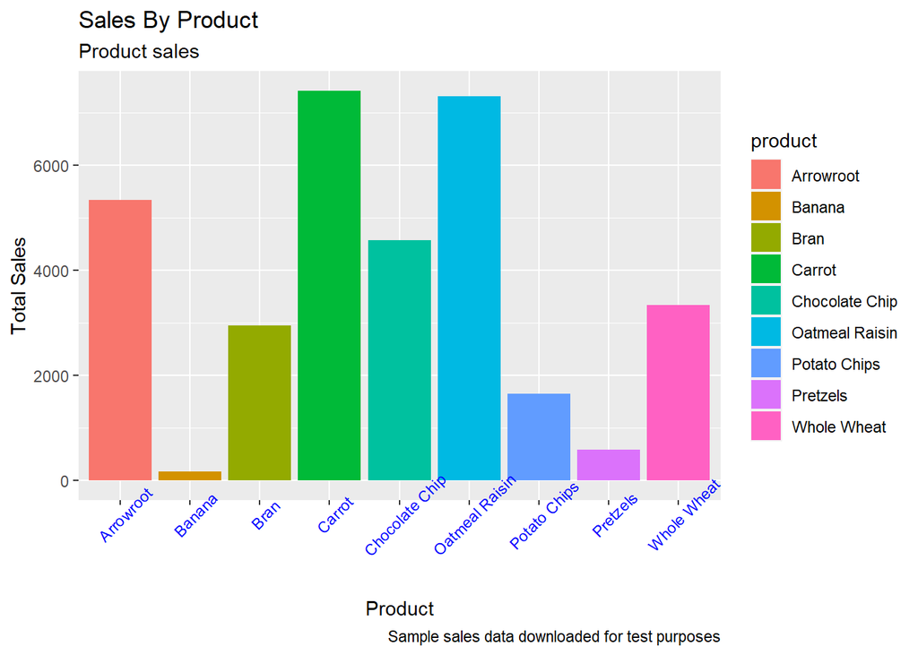

```r
 ggplot(data = my_sales_clean_data ,aes(x= product, y= total_price, fill =product))+
geom_col() +
   theme(axis.text.x = element_text(angle = 45,colour = "blue"))+
   labs(title ="Sales By Product",
        subtitle = "Product sales",
        caption = "Sample sales data downloaded for test purposes",
        x="Product",
        y="Total Sales")
```

### Sales By City by category(wrap)

Here we get a view of all Sales done for each City

[figure not shown]

```r
 ggplot(data = my_sales_clean_data)+ geom_col(mapping = aes(x= category, y= total_price, fill =category))+
   facet_wrap(~city)+
  labs(title ="Sales By City by category",
      #  subtitle = "Sales By City by category",
        caption = "Sample sales data downloaded for test purposes",
        x="Category",
        y="Total Sales")
```

### Sales By City by category(grid)

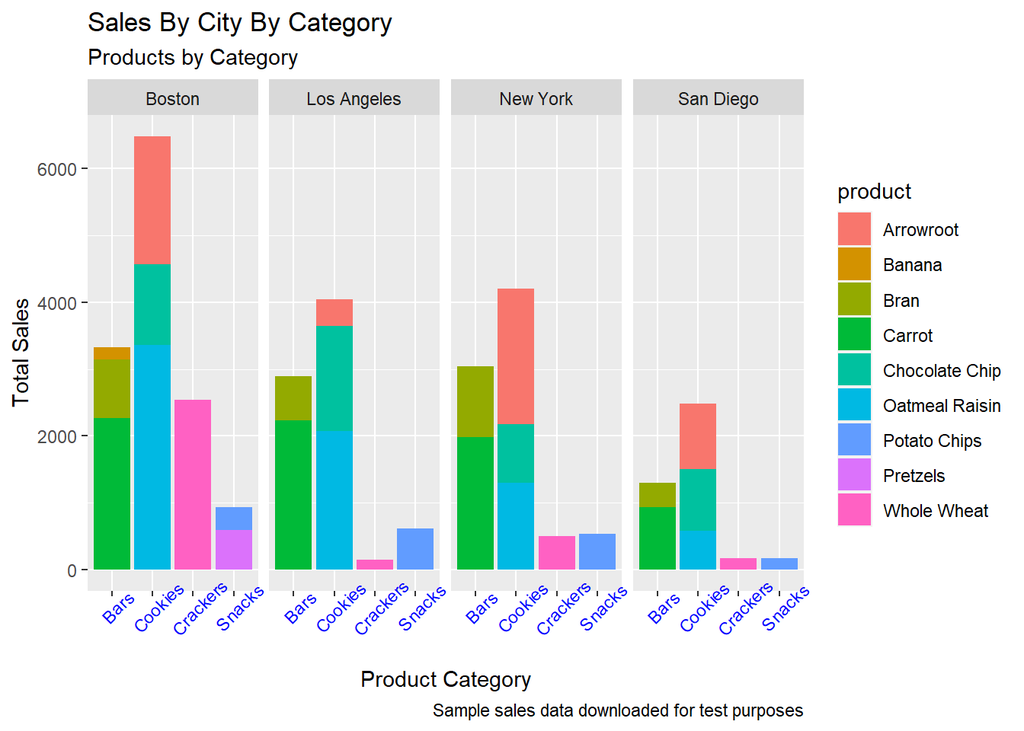

```r
ggplot(data = my_sales_clean_data)+ geom_col(mapping = aes(x= category, y= total_price, fill =product))+
   facet_grid(~city)+
   theme(axis.text.x = element_text(angle = 45,colour = "blue"))+
   labs(title ="Sales By City By Category",
        subtitle = "Products by Category",
        caption = "Sample sales data downloaded for test purposes",
 x="Product Category",
 y="Total Sales")
```

### Sales By order Date

Total sales each month for all combined products each month

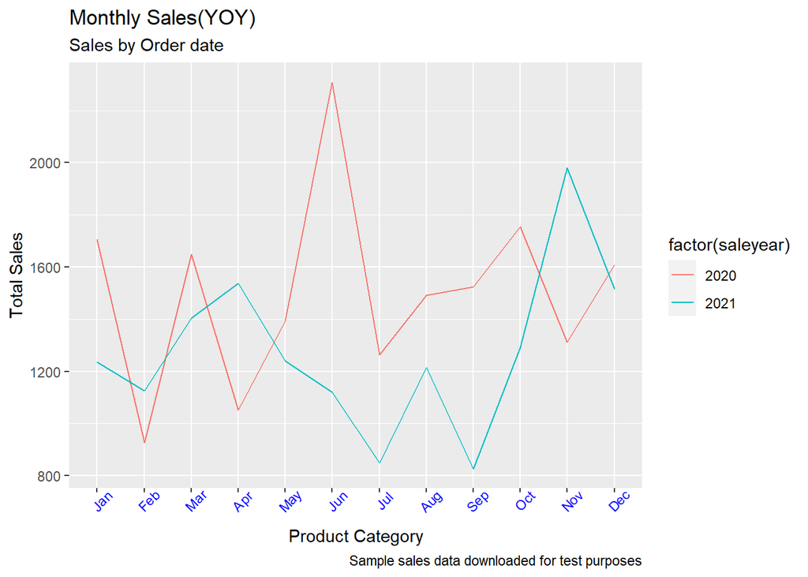

```r
 my_sales_clean_data %>%
   mutate(month_name = month(order_date, label = TRUE)) %>%
   mutate(saleyear = year(order_date)) %>%
   group_by(saleyear,month_name) %>%
   summarise( total_sales_by_date = sum(total_price)) %>%
 ggplot( mapping = aes(x= month_name, y= total_sales_by_date,color = factor(saleyear), group = factor(saleyear))) +
   geom_line()+
   theme(axis.text.x = element_text(angle = 45,colour = "blue"))+
   labs(title ="Monthly Sales(YOY)",
        subtitle = "Sales by Order date",
        caption = "Sample sales data downloaded for test purposes",
        x="Product Category",
        y="Total Sales")
```

### Month Sales By Product(multiple lines) (2020)

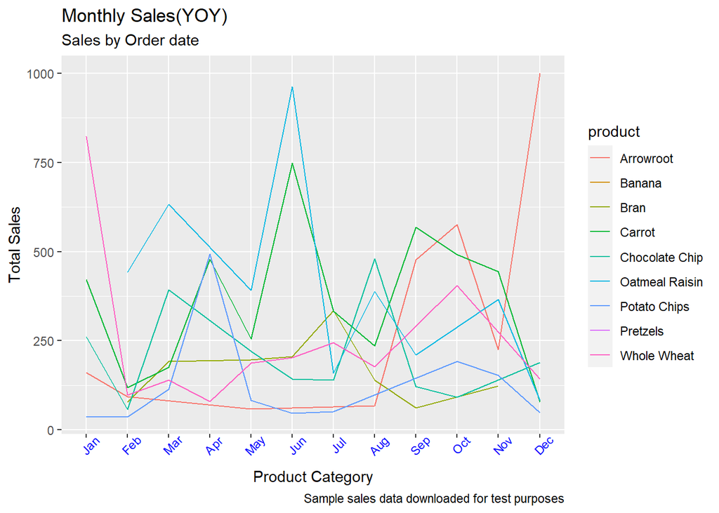

```r
my_sales_clean_data %>%
   mutate(month_name = month(order_date, label = TRUE)) %>%
   mutate(saleyear = year(order_date)) %>%
    filter(saleyear== 2020) %>%
   group_by(saleyear,month_name,product) %>%
   summarise( total_sales_by_date = sum(total_price)) %>%
 ggplot( mapping = aes(x= month_name, y= total_sales_by_date,color = product, group = factor(product))) +
   geom_line()+
   theme(axis.text.x = element_text(angle = 45,colour = "blue"))+
   labs(title ="Monthly Sales(YOY)",
        subtitle = "Sales by Order date",
        caption = "Sample sales data downloaded for test purposes",
        x="Product Category",
        y="Total Sales")
```

### Month Sales By Category(multiple lines) (2020)

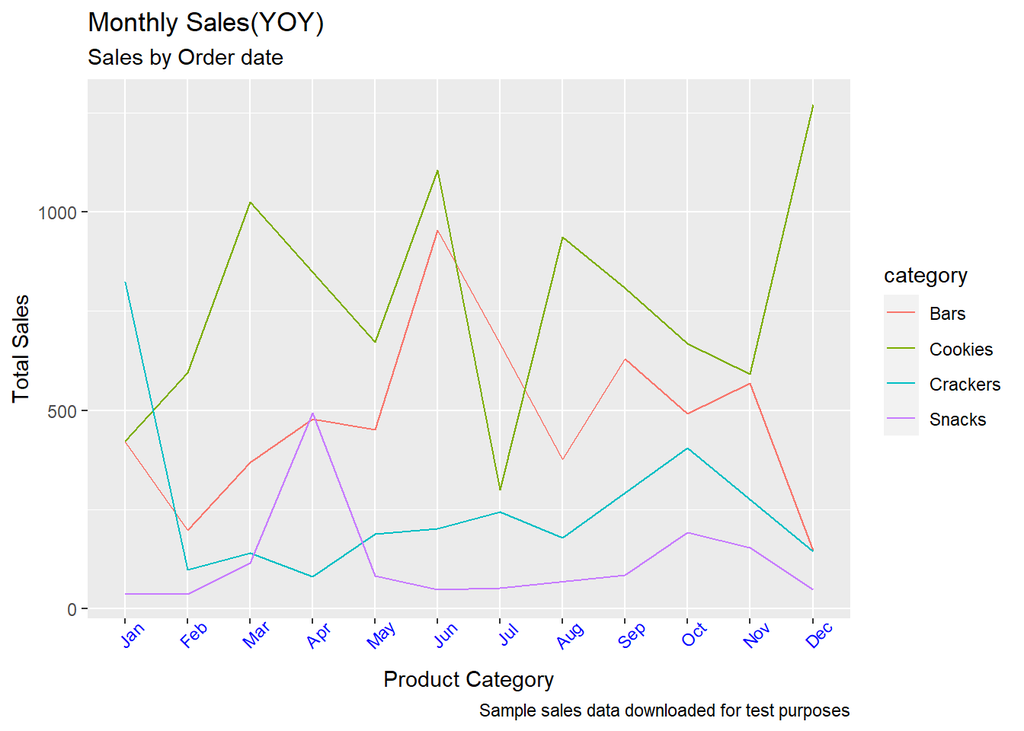

```r
my_sales_clean_data %>%
   mutate(month_name = month(order_date, label = TRUE)) %>%
   mutate(saleyear = year(order_date)) %>%
    filter(saleyear== 2020) %>%
   group_by(month_name,category ) %>%
   summarise( total_sales_by_date = sum(total_price)) %>%
 ggplot( mapping = aes(x= month_name, y= total_sales_by_date,color = category , group = factor(category ))) +
   geom_line()+
   theme(axis.text.x = element_text(angle = 45,colour = "blue"))+
   labs(title ="Monthly Sales(YOY)",
        subtitle = "Sales by Order date",
        caption = "Sample sales data downloaded for test purposes",
        x="Product Category",
        y="Total Sales")
```

### Month Sales By Category (Pie) (2020)

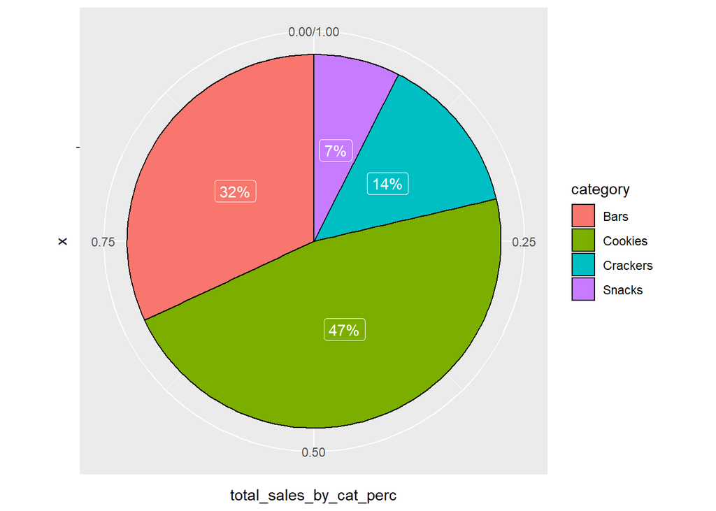

```r
my_sales_clean_data %>%
 # mutate(month_name = month(order_date, label = TRUE)) %>%
   mutate(saleyear = year(order_date)) %>%
    filter(saleyear== 2020) %>%
   group_by(category) %>%
   summarise( total_sales_by_cat = sum(total_price)) %>%
   mutate(total_sales_by_cat_perc = `total_sales_by_cat` / sum(`total_sales_by_cat`)) %>%
   mutate(labels = scales::percent(total_sales_by_cat_perc,accuracy = 1L)) %>%
   ggplot( aes(x = "", y = total_sales_by_cat_perc, fill = category)) +
   geom_col(color = "black") +
   geom_label(aes(label =  labels),
              color = "white",
              position = position_stack(vjust = 0.5),
              show.legend = FALSE) +
   coord_polar(theta = "y")
```